# Ecotourism Hard Task

Author

Mahjabin Siddika Oyshi

# Hard Task

When I first approached this task, I assumed I would need a predictive model. But looking at the data, I realised we are not actually predicting future weather—only using historical patterns.I still used a Poisson model to estimate how expected sightings vary with weather and time, and then ranked the most favourable conditions.

Because the response variable is a count (number of sightings per hour), a Poisson model is a natural starting point. I briefly checked the mean–variance relationship to see if this assumption was reasonable.

## Glowworms: data exploration

First I explored glowworm sightings and matching weather data.

```r
library(ggplot2)
library(dplyr)
library(lubridate)
library(ecotourism)

data("glowworms")
data("weather")

joined <- glowworms |>
  left_join(weather, by = c("date", "ws_id")) |>
  mutate(month = month(date))

hourly_counts <- joined |>
  filter(!is.na(hour), !is.na(temp)) |>
  group_by(date, hour) |>
  summarise(
    n_sightings = n(),
    temp        = mean(temp, na.rm = TRUE),
    prcp        = mean(prcp, na.rm = TRUE),
    wind_speed  = mean(wind_speed, na.rm = TRUE),
    dewp        = mean(dewp, na.rm = TRUE),
    month       = first(month),
    .groups = "drop"
  )

mean(hourly_counts$n_sightings)
```

```
[1] 1.833333
```

```r
var(hourly_counts$n_sightings)
```

```
[1] 2.566667
```

```r
var(hourly_counts$n_sightings) / mean(hourly_counts$n_sightings)
```

```
[1] 1.4
```

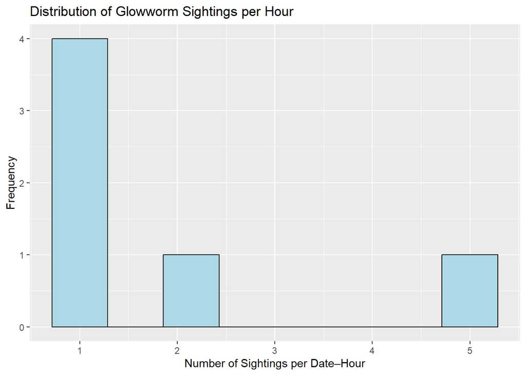

```r
ggplot(hourly_counts, aes(x = n_sightings)) +
  geom_histogram(bins = 8, fill = "lightblue", color = "black") +
  labs(
    title = "Distribution of Glowworm Sightings per Hour",
    x = "Number of Sightings per Date–Hour",
    y = "Frequency"
  )
```

```markdown
After joining and aggregating, only six date–hour rows remained for
glowworms.This made the model unstable, with coefficients that were not estimable. Rather than forcing a model on insufficient data, I switched to the Gouldian Finch dataset, which has much better coverage.
```

## Gouldian Finch model

```r
library(lubridate)

#Load data
data("gouldian_finch")
data("weather")

#Joining Finch records with weather
gould_joined <- gouldian_finch |>
  left_join(
    weather |>
      select(ws_id, date, temp, prcp, wind_speed, dewp),
    by = c("ws_id", "date")
  ) |>
  mutate(month = month(date))

#Count how many finches are seen in each date–hour slot and attach typical weather for that slot
gould_hourly <- gould_joined |>
  filter(!is.na(hour), !is.na(temp)) |>
  group_by(date, hour) |>
  summarise(
    n_sightings = n(),
    temp        = mean(temp,       na.rm = TRUE),
    prcp        = mean(prcp,       na.rm = TRUE),
    wind_speed  = mean(wind_speed, na.rm = TRUE),
    dewp        = mean(dewp,       na.rm = TRUE),
    month       = first(month),
    .groups     = "drop"
  )

nrow(gould_hourly)        # check how many rows you have
```

```
[1] 1466
```

```r
# The ratio is about 0.67, which is somewhat below 1, indicating mild underdispersion. While not a perfect Poisson fit, it is still reasonable for exploratory modelling.

# Prepare data for modelling: drop rows with missing predictors
gould_mod <- gould_hourly |>
  filter(!is.na(temp),
         !is.na(prcp),
         !is.na(wind_speed),
         !is.na(dewp),
         !is.na(month),
         !is.na(hour))

nrow(gould_mod)      # should match the number of rows used in the model
```

```
[1] 1448
```

```r
# Check Poisson assumption for Gouldian Finch counts
mean(gould_mod$n_sightings)
```

```
[1] 1.447514
```

```r
var(gould_mod$n_sightings)
```

```
[1] 0.9758197
```

```r
var(gould_mod$n_sightings) / mean(gould_mod$n_sightings)
```

```
[1] 0.674135
```

```r
# Poisson GLM on Finch counts
gould_model <- glm(
  n_sightings ~ temp + prcp + wind_speed + dewp + month + hour,
  family = poisson,
  data   = gould_mod
)

summary(gould_model)
```

```
Call:
glm(formula = n_sightings ~ temp + prcp + wind_speed + dewp +
    month + hour, family = poisson, data = gould_mod)

Coefficients:
              Estimate Std. Error z value Pr(>|z|)
(Intercept) -0.1072409  0.2274747  -0.471  0.63733
temp         0.0008166  0.0090404   0.090  0.92803
prcp         0.0021273  0.0047622   0.447  0.65509
wind_speed   0.0109660  0.0272621   0.402  0.68751
dewp         0.0132403  0.0045697   2.897  0.00376 **
month        0.0284134  0.0097169   2.924  0.00345 **
hour         0.0028243  0.0047748   0.592  0.55418
---
Signif. codes:  0 '***' 0.001 '**' 0.01 '*' 0.05 '.' 0.1 ' ' 1

(Dispersion parameter for poisson family taken to be 1)

    Null deviance: 650.21  on 1447  degrees of freedom
Residual deviance: 622.87  on 1441  degrees of freedom
AIC: 3853.5

Number of Fisher Scoring iterations: 5
```

```r
#Calculate Incident Rate Ratios(IRR)
exp(coef(gould_model))
```

```
(Intercept)        temp        prcp  wind_speed        dewp       month
  0.8983093   1.0008169   1.0021295   1.0110263   1.0133283   1.0288209
       hour
  1.0028283
```

```r
# Score each date–hour and pull out the top 5 times
gould_mod$predicted <- predict(gould_model, type = "response")

gould_top5 <- gould_mod |>
  arrange(desc(predicted)) |>
  slice_head(n = 5)

gould_top5
```

```
# A tibble: 5 × 9
  date        hour n_sightings  temp  prcp wind_speed  dewp month predicted
  <date>     <int>       <int> <dbl> <dbl>      <dbl> <dbl> <dbl>     <dbl>
1 2022-12-23    15           1  26.6  16.8        4.2  23.6    12      2.00
2 2021-12-25     7           1  25.4  22.1        4.3  23.3    12      1.97
3 2022-10-08    18           1  28.4  32.5        2.9  23.6    10      1.94
4 2022-10-08    17           9  28.4  32.5        2.9  23.6    10      1.94
5 2022-12-22     9           1  26.8  13.7        3.6  23.3    12      1.93
```

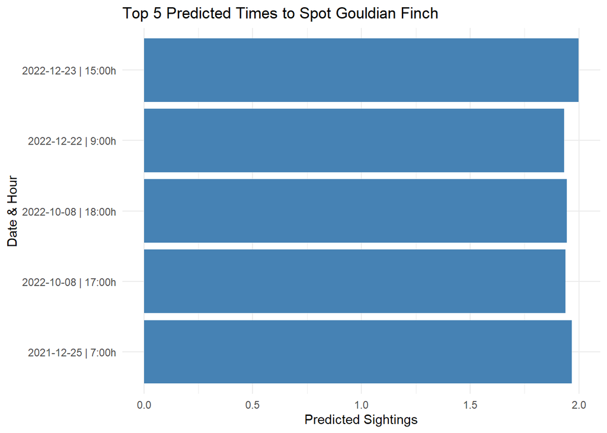

```r
# 7. Plot
ggplot(gould_top5, aes(x = paste0(date, " | ", hour, ":00h"),
                       y = predicted)) +
  geom_col(fill = "steelblue") +
  coord_flip() +
  labs(
    title = "Top 5 Predicted Times to Spot Gouldian Finch",
    x = "Date & Hour",
    y = "Predicted Sightings"
  ) +
  theme_minimal()
```

```r
#weather effects are quite small: temperature, rain, wind, and time of day barely change expected sightings. Humidity and time of year matter a bit more—more humid days and later months in the season are linked to slightly higher Finch counts.
# Example: predict Finch counts for a given weather/time combo
new_data <- data.frame(
  temp       = 25,
  prcp       = 0,
  wind_speed = 3,
  dewp       = 18,
  month      = 6,
  hour       = 7
)
#Check overdispersion

predicted_counts <- predict(gould_model, newdata = new_data, type = "response")
round(predicted_counts, 1)
```

```
  1
1.5
```

```r
residual_deviance <- gould_model$deviance
df_residual       <- gould_model$df.residual
dispersion        <- residual_deviance / df_residual

dispersion  # ~1 is fine; > 1.5 suggests overdispersion
```

```
[1] 0.4322453
```

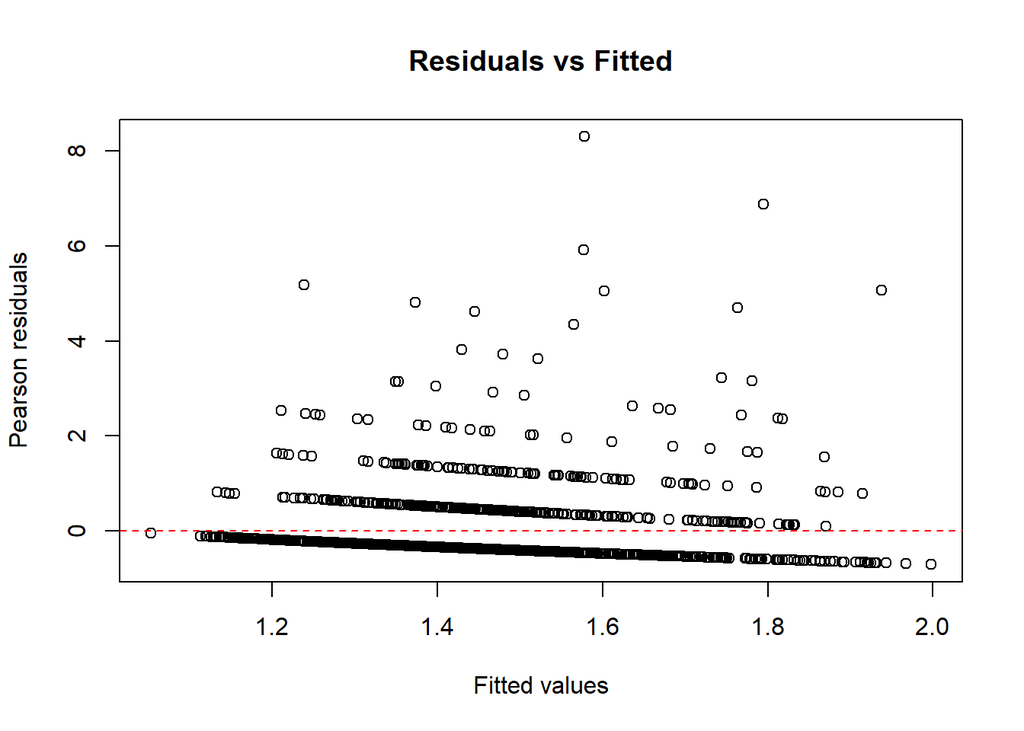

```r
#Basic residual plot
fitted_values      <- fitted(gould_model)
pearson_residuals  <- residuals(gould_model, type = "pearson")

plot(fitted_values, pearson_residuals,
     xlab = "Fitted values", ylab = "Pearson residuals",
     main = "Residuals vs Fitted")
abline(h = 0, col = "red", lty = 2)
```

The variance–mean ratio for Finch counts is about 0.67, and the dispersion statistic is below 1, so a Poisson model is appropriate. The IRRs show very small effects for temperature, rain, wind, and hour, with slightly stronger positive effects for dew point (humidity) and month of year.

The residuals vs fitted plot shows a roughly random scatter around zero without strong patterns, supporting that the Poisson model fits the Finch count data reasonably well.

## Function: predict_top_sightings

```r
predict_top_sightings <- function(occurrence, n_top = 5) {

  weather <- ecotourism::weather   # use built-in weather data

  joined <- occurrence |>
    dplyr::left_join(
      weather |>
        dplyr::select(ws_id, date, temp, prcp, wind_speed, dewp),
      by = c("ws_id", "date")
    ) |>
    dplyr::mutate(month = lubridate::month(date))

  hourly <- joined |>
    dplyr::filter(
      !is.na(hour),
      !is.na(temp), !is.na(prcp),
      !is.na(wind_speed), !is.na(dewp)
    ) |>
    dplyr::group_by(date, hour) |>
    dplyr::summarise(
      n_sightings = dplyr::n(),
      temp        = mean(temp,       na.rm = TRUE),
      prcp        = mean(prcp,       na.rm = TRUE),
      wind_speed  = mean(wind_speed, na.rm = TRUE),
      dewp        = mean(dewp,       na.rm = TRUE),
      month       = dplyr::first(month),
      .groups     = "drop"
    )

  model <- glm(
    n_sightings ~ temp + prcp + wind_speed + dewp + month + hour,
    family = poisson,  # or quasipoisson
    data   = hourly
  )

  hourly$predicted <- predict(model, type = "response")

  hourly |>
    dplyr::arrange(dplyr::desc(predicted)) |>
    dplyr::mutate(
      rank       = dplyr::row_number(),
      weekday    = weekdays(date),
      month_name = lubridate::month(date, label = TRUE, abbr = FALSE)
    ) |>
    dplyr::select(
      rank, month_name, weekday, hour, n_sightings,
      mean_temp = temp, mean_prcp = prcp,
      mean_wind = wind_speed, mean_dewp = dewp,
      predicted
    ) |>
    dplyr::slice_head(n = n_top)
}
```

```r
gould_top5 <- predict_top_sightings(gouldian_finch, n_top = 5)
gould_top5
```

```
# A tibble: 5 × 10
   rank month_name weekday   hour n_sightings mean_temp mean_prcp mean_wind
  <int> <ord>      <chr>    <int>       <int>     <dbl>     <dbl>     <dbl>
1     1 December   Friday      15           1      26.6      16.8       4.2
2     2 December   Saturday     7           1      25.4      22.1       4.3
3     3 October    Saturday    18           1      28.4      32.5       2.9
4     4 October    Saturday    17           9      28.4      32.5       2.9
5     5 December   Thursday     9           1      26.8      13.7       3.6
# ℹ 2 more variables: mean_dewp <dbl>, predicted <dbl>
```

The `predict_top_sightings()` function takes any occurrence and matching weather dataset, fits a Poisson model to hourly counts, and returns the top five date–hour combinations with the highest predicted sightings. Applied to the Gouldian Finch data, it suggests warm, humid mornings and afternoons in October and December, with about two birds expected in those hours.That said, most of the weather variables had very small effects, suggesting that short-term conditions like rain or temperature do not strongly influence sightings. I found this a bit unexpected, as I initially thought those factors would play a bigger role.